# Balancing NASA’s Asteroid Dataset and Buiding Models for Predicting Hazard Levels

Vishal Bakshi, Pratiksha Dange, Sudanshu Dotel, Qibin Huang

### Importing Dataset

```r
df <- read.csv('/Users/pratikshadange/Documents/GitHub/6101_Project_Data_Diggers/Datasets/Asteroid_Hazard_Classification.csv')

head(df)
```

Neo.Reference.ID Name Absolute.Magnitude Est.Dia.in.KM.min. 1 3703080 3703080 21.6 0.127219879 2 3723955 3723955 21.3 0.146067964 3 2446862 2446862 20.3 0.231502122 4 3092506 3092506 27.4 0.008801465 5 3514799 3514799 21.6 0.127219879 6 3671135 3671135 19.6 0.319561887 Est.Dia.in.KM.max. Est.Dia.in.Feet.min. Est.Dia.in.Feet.max. 1 0.28447230 417.3881 933.30809 2 0.32661790 479.2256 1071.58106 3 0.51765448 759.5214 1698.34153 4 0.01968068 28.8762 64.56914 5 0.28447230 417.3881 933.30809 6 0.71456210 1048.4314 2344.36393 Close.Approach.Date Epoch.Date.Close.Approach Relative.Velocity.km.per.sec 1 1/1/95 7.89e+11 6.115834 2 1/1/95 7.89e+11 18.113985 3 1/8/95 7.90e+11 7.590711 4 1/15/95 7.90e+11 11.173875 5 1/15/95 7.90e+11 9.840831 6 1/15/95 7.90e+11 10.808844 Miss.Dist..Astronomical. Miss.Dist..lunar. Miss.Dist..kilometers. 1 0.41948253 163.17871 62753692 2 0.38301446 148.99263 57298148 3 0.05095602 19.82189 7622912 4 0.28532233 110.99039 42683616 5 0.40783217 158.64671 61010824 6 0.39278478 152.79327 58759768 Orbiting.Body Orbit.ID Orbit.Determination.Date Orbit.Uncertainity 1 Earth 17 4/6/17 8:36 5 2 Earth 21 4/6/17 8:32 3 3 Earth 22 4/6/17 9:20 0 4 Earth 7 4/6/17 9:15 6 5 Earth 25 4/6/17 8:57 1 6 Earth 40 6/4/17 6:16 1 Minimum.Orbit.Intersection Jupiter.Tisserand.Invariant Epoch.Osculation 1 0.0252819 4.634 2458000 2 0.1869350 5.457 2458000 3 0.0430579 4.557 2458000 4 0.0055118 5.093 2458000 5 0.0347980 5.154 2458000 6 0.2722130 4.724 2458000 Eccentricity Semi.Major.Axis Inclination Asc.Node.Longitude Orbital.Period 1 0.4255491 1.407011 6.025981 314.37391 609.5998 2 0.3516743 1.107776 28.412996 136.71724 425.8693 3 0.3482483 1.458824 4.237961 259.47598 643.5802 4 0.2165783 1.255903 7.905894 57.17327 514.0821 5 0.2104479 1.225615 16.793382 84.62931 495.5978 6 0.5634411 1.323532 17.927751 178.97195 556.1606 Perihelion.Distance Perihelion.Arg Aphelion.Dist Perihelion.Time Mean.Anomaly 1 0.8082589 57.25747 2.005764 2458162 264.83753 2 0.7181996 313.09197 1.497352 2457795 173.74111 3 0.9507910 248.41504 1.966857 2458120 292.89365 4 0.9839016 18.70770 1.527904 2457902 68.74101 5 0.9676866 158.26360 1.483543 2457814 135.14213 6 0.5777998 198.14597 2.069265 2458009 354.23737 Mean.Motion Equinox Hazardous 1 0.5905514 J2000 TRUE 2 0.8453298 J2000 FALSE 3 0.5593708 J2000 TRUE 4 0.7002772 J2000 FALSE 5 0.7263954 J2000 TRUE 6 0.6472951 J2000 FALSE ### check Null Values

```r
null_values <- colSums(is.na(df))
print("Null Values in Each Column:")
```

[1] “Null Values in Each Column:”

```r
print(null_values)
```

```
        Neo.Reference.ID                         Name
                       0                            0
      Absolute.Magnitude           Est.Dia.in.KM.min.
                       0                            0
      Est.Dia.in.KM.max.         Est.Dia.in.Feet.min.
                       0                            0
    Est.Dia.in.Feet.max.          Close.Approach.Date
                       0                            0
```

Epoch.Date.Close.Approach Relative.Velocity.km.per.sec 0 0 Miss.Dist..Astronomical. Miss.Dist..lunar. 0 0 Miss.Dist..kilometers. Orbiting.Body 0 0 Orbit.ID Orbit.Determination.Date 0 0 Orbit.Uncertainity Minimum.Orbit.Intersection 0 0 Jupiter.Tisserand.Invariant Epoch.Osculation 0 0 Eccentricity Semi.Major.Axis 0 0 Inclination Asc.Node.Longitude 0 0 Orbital.Period Perihelion.Distance 0 0 Perihelion.Arg Aphelion.Dist 0 0 Perihelion.Time Mean.Anomaly 0 0 Mean.Motion Equinox 0 0 Hazardous 0 # Display data types of all columns

```r
print("Data Types of Columns:")
```

[1] “Data Types of Columns:”

```r
str(df)
```

‘data.frame’: 3692 obs. of 33 variables: $ Neo.Reference.ID : int 3703080 3723955 2446862 3092506 3514799 3671135 2495323 2153315 2162463 2306383 … $ Name : int 3703080 3723955 2446862 3092506 3514799 3671135 2495323 2153315 2162463 2306383 … $ Absolute.Magnitude : num 21.6 21.3 20.3 27.4 21.6 19.6 19.6 19.2 17.8 21.5 … $ Est.Dia.in.KM.min. : num 0.1272 0.1461 0.2315 0.0088 0.1272 … $ Est.Dia.in.KM.max. : num 0.2845 0.3266 0.5177 0.0197 0.2845 … $ Est.Dia.in.Feet.min. : num 417.4 479.2 759.5 28.9 417.4 … $ Est.Dia.in.Feet.max. : num 933.3 1071.6 1698.3 64.6 933.3 … $ Close.Approach.Date : chr “1/1/95” “1/1/95” “1/8/95” “1/15/95” … $ Epoch.Date.Close.Approach : num 7.89e+11 7.89e+11 7.90e+11 7.90e+11 7.90e+11 … $ Relative.Velocity.km.per.sec: num 6.12 18.11 7.59 11.17 9.84 … $ Miss.Dist..Astronomical. : num 0.419 0.383 0.051 0.285 0.408 … $ Miss.Dist..lunar. : num 163.2 149 19.8 111 158.6 … $ Miss.Dist..kilometers. : num 62753692 57298148 7622912 42683616 61010824 … $ Orbiting.Body : chr “Earth” “Earth” “Earth” “Earth” … $ Orbit.ID : int 17 21 22 7 25 40 43 22 100 30 … $ Orbit.Determination.Date : chr “4/6/17 8:36” “4/6/17 8:32” “4/6/17 9:20” “4/6/17 9:15” … $ Orbit.Uncertainity : int 5 3 0 6 1 1 1 0 0 0 … $ Minimum.Orbit.Intersection : num 0.02528 0.18693 0.04306 0.00551 0.0348 … $ Jupiter.Tisserand.Invariant : num 4.63 5.46 4.56 5.09 5.15 … $ Epoch.Osculation : num 2458000 2458000 2458000 2458000 2458000 … $ Eccentricity : num 0.426 0.352 0.348 0.217 0.21 … $ Semi.Major.Axis : num 1.41 1.11 1.46 1.26 1.23 … $ Inclination : num 6.03 28.41 4.24 7.91 16.79 … $ Asc.Node.Longitude : num 314.4 136.7 259.5 57.2 84.6 … $ Orbital.Period : num 610 426 644 514 496 … $ Perihelion.Distance : num 0.808 0.718 0.951 0.984 0.968 … $ Perihelion.Arg : num 57.3 313.1 248.4 18.7 158.3 … $ Aphelion.Dist : num 2.01 1.5 1.97 1.53 1.48 … $ Perihelion.Time : num 2458162 2457795 2458120 2457902 2457814 … $ Mean.Anomaly : num 264.8 173.7 292.9 68.7 135.1 … $ Mean.Motion : num 0.591 0.845 0.559 0.7 0.726 … $ Equinox : chr “J2000” “J2000” “J2000” “J2000” … $ Hazardous : logi TRUE FALSE TRUE FALSE TRUE FALSE …

```r
# Remove the 'Equinox' column using subset()
df <- subset(df, select = -c(Equinox))
# Display the first few rows of the updated DataFrame
head(df)
```

Neo.Reference.ID Name Absolute.Magnitude Est.Dia.in.KM.min. 1 3703080 3703080 21.6 0.127219879 2 3723955 3723955 21.3 0.146067964 3 2446862 2446862 20.3 0.231502122 4 3092506 3092506 27.4 0.008801465 5 3514799 3514799 21.6 0.127219879 6 3671135 3671135 19.6 0.319561887 Est.Dia.in.KM.max. Est.Dia.in.Feet.min. Est.Dia.in.Feet.max. 1 0.28447230 417.3881 933.30809 2 0.32661790 479.2256 1071.58106 3 0.51765448 759.5214 1698.34153 4 0.01968068 28.8762 64.56914 5 0.28447230 417.3881 933.30809 6 0.71456210 1048.4314 2344.36393 Close.Approach.Date Epoch.Date.Close.Approach Relative.Velocity.km.per.sec 1 1/1/95 7.89e+11 6.115834 2 1/1/95 7.89e+11 18.113985 3 1/8/95 7.90e+11 7.590711 4 1/15/95 7.90e+11 11.173875 5 1/15/95 7.90e+11 9.840831 6 1/15/95 7.90e+11 10.808844 Miss.Dist..Astronomical. Miss.Dist..lunar. Miss.Dist..kilometers. 1 0.41948253 163.17871 62753692 2 0.38301446 148.99263 57298148 3 0.05095602 19.82189 7622912 4 0.28532233 110.99039 42683616 5 0.40783217 158.64671 61010824 6 0.39278478 152.79327 58759768 Orbiting.Body Orbit.ID Orbit.Determination.Date Orbit.Uncertainity 1 Earth 17 4/6/17 8:36 5 2 Earth 21 4/6/17 8:32 3 3 Earth 22 4/6/17 9:20 0 4 Earth 7 4/6/17 9:15 6 5 Earth 25 4/6/17 8:57 1 6 Earth 40 6/4/17 6:16 1 Minimum.Orbit.Intersection Jupiter.Tisserand.Invariant Epoch.Osculation 1 0.0252819 4.634 2458000 2 0.1869350 5.457 2458000 3 0.0430579 4.557 2458000 4 0.0055118 5.093 2458000 5 0.0347980 5.154 2458000 6 0.2722130 4.724 2458000 Eccentricity Semi.Major.Axis Inclination Asc.Node.Longitude Orbital.Period 1 0.4255491 1.407011 6.025981 314.37391 609.5998 2 0.3516743 1.107776 28.412996 136.71724 425.8693 3 0.3482483 1.458824 4.237961 259.47598 643.5802 4 0.2165783 1.255903 7.905894 57.17327 514.0821 5 0.2104479 1.225615 16.793382 84.62931 495.5978 6 0.5634411 1.323532 17.927751 178.97195 556.1606 Perihelion.Distance Perihelion.Arg Aphelion.Dist Perihelion.Time Mean.Anomaly 1 0.8082589 57.25747 2.005764 2458162 264.83753 2 0.7181996 313.09197 1.497352 2457795 173.74111 3 0.9507910 248.41504 1.966857 2458120 292.89365 4 0.9839016 18.70770 1.527904 2457902 68.74101 5 0.9676866 158.26360 1.483543 2457814 135.14213 6 0.5777998 198.14597 2.069265 2458009 354.23737 Mean.Motion Hazardous 1 0.5905514 TRUE 2 0.8453298 FALSE 3 0.5593708 TRUE 4 0.7002772 FALSE 5 0.7263954 TRUE 6 0.6472951 FALSE

```r
# Convert Hazardous column values to integers (1 for TRUE, 0 for FALSE)

df$Hazardous <- ifelse(df$Hazardous == TRUE, 1, 0)

# Display the first few rows of the updated DataFrame
head(df)
```

Neo.Reference.ID Name Absolute.Magnitude Est.Dia.in.KM.min. 1 3703080 3703080 21.6 0.127219879 2 3723955 3723955 21.3 0.146067964 3 2446862 2446862 20.3 0.231502122 4 3092506 3092506 27.4 0.008801465 5 3514799 3514799 21.6 0.127219879 6 3671135 3671135 19.6 0.319561887 Est.Dia.in.KM.max. Est.Dia.in.Feet.min. Est.Dia.in.Feet.max. 1 0.28447230 417.3881 933.30809 2 0.32661790 479.2256 1071.58106 3 0.51765448 759.5214 1698.34153 4 0.01968068 28.8762 64.56914 5 0.28447230 417.3881 933.30809 6 0.71456210 1048.4314 2344.36393 Close.Approach.Date Epoch.Date.Close.Approach Relative.Velocity.km.per.sec 1 1/1/95 7.89e+11 6.115834 2 1/1/95 7.89e+11 18.113985 3 1/8/95 7.90e+11 7.590711 4 1/15/95 7.90e+11 11.173875 5 1/15/95 7.90e+11 9.840831 6 1/15/95 7.90e+11 10.808844 Miss.Dist..Astronomical. Miss.Dist..lunar. Miss.Dist..kilometers. 1 0.41948253 163.17871 62753692 2 0.38301446 148.99263 57298148 3 0.05095602 19.82189 7622912 4 0.28532233 110.99039 42683616 5 0.40783217 158.64671 61010824 6 0.39278478 152.79327 58759768 Orbiting.Body Orbit.ID Orbit.Determination.Date Orbit.Uncertainity 1 Earth 17 4/6/17 8:36 5 2 Earth 21 4/6/17 8:32 3 3 Earth 22 4/6/17 9:20 0 4 Earth 7 4/6/17 9:15 6 5 Earth 25 4/6/17 8:57 1 6 Earth 40 6/4/17 6:16 1 Minimum.Orbit.Intersection Jupiter.Tisserand.Invariant Epoch.Osculation 1 0.0252819 4.634 2458000 2 0.1869350 5.457 2458000 3 0.0430579 4.557 2458000 4 0.0055118 5.093 2458000 5 0.0347980 5.154 2458000 6 0.2722130 4.724 2458000 Eccentricity Semi.Major.Axis Inclination Asc.Node.Longitude Orbital.Period 1 0.4255491 1.407011 6.025981 314.37391 609.5998 2 0.3516743 1.107776 28.412996 136.71724 425.8693 3 0.3482483 1.458824 4.237961 259.47598 643.5802 4 0.2165783 1.255903 7.905894 57.17327 514.0821 5 0.2104479 1.225615 16.793382 84.62931 495.5978 6 0.5634411 1.323532 17.927751 178.97195 556.1606 Perihelion.Distance Perihelion.Arg Aphelion.Dist Perihelion.Time Mean.Anomaly 1 0.8082589 57.25747 2.005764 2458162 264.83753 2 0.7181996 313.09197 1.497352 2457795 173.74111 3 0.9507910 248.41504 1.966857 2458120 292.89365 4 0.9839016 18.70770 1.527904 2457902 68.74101 5 0.9676866 158.26360 1.483543 2457814 135.14213 6 0.5777998 198.14597 2.069265 2458009 354.23737 Mean.Motion Hazardous 1 0.5905514 1 2 0.8453298 0 3 0.5593708 1 4 0.7002772 0 5 0.7263954 1 6 0.6472951 0 ### Hazardous vs Non-Hazardous Plot

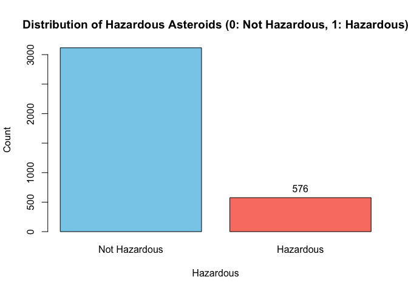

```r
# Load the ggplot2 library
library(ggplot2)

# Count the occurrences of 0s and 1s in the 'Hazardous' column
hazardous_counts <- table(df$Hazardous)

# Create a bar plot
barplot(hazardous_counts,
        main = 'Distribution of Hazardous Asteroids (0: Not Hazardous, 1: Hazardous)',
        xlab = 'Hazardous',
        ylab = 'Count',
        col = c('skyblue', 'salmon'),
        ylim = c(0, max(hazardous_counts) + 1),
        names.arg = c('Not Hazardous', 'Hazardous'),
        beside = TRUE)

# Add counts on top of the bars
text(x = barplot(hazardous_counts, plot = FALSE),
     y = ifelse(hazardous_counts > 0, hazardous_counts + 0.1, 0.1),
     labels = as.character(hazardous_counts),
     pos = 3)
```

# Display the number of unique values in each object-type variable

```r
# Select columns of type 'character'
object_columns <- sapply(df, class) == "character"

# Calculate the number of unique values for each 'character' column
unique_values <- sapply(df[, object_columns], function(x) length(unique(x)))

# Display the number of unique values in each 'character' column
for (i in seq_along(unique_values)) {
  cat("Number of unique values in '", names(unique_values)[i], "': ", unique_values[i], "\n")
}
```

Number of unique values in ’ Close.Approach.Date ‘: 770 Number of unique values in’ Orbiting.Body ‘: 1 Number of unique values in’ Orbit.Determination.Date ’: 457

# Identify columns to drop

```r
columns_to_drop <- c('Orbiting.Body', 'Close.Approach.Date', 'Orbit.Determination.Date','Neo.Reference.ID','Name','Epoch.Date.Close.Approach','Equinox','Orbit.Determination.Date')

#drop identified columns
df <- df[, !(names(df) %in% columns_to_drop)]


# Display the first few rows of the updated DataFrame
head(df)
```

Absolute.Magnitude Est.Dia.in.KM.min. Est.Dia.in.KM.max. Est.Dia.in.Feet.min. 1 21.6 0.127219879 0.28447230 417.3881 2 21.3 0.146067964 0.32661790 479.2256 3 20.3 0.231502122 0.51765448 759.5214 4 27.4 0.008801465 0.01968068 28.8762 5 21.6 0.127219879 0.28447230 417.3881 6 19.6 0.319561887 0.71456210 1048.4314 Est.Dia.in.Feet.max. Relative.Velocity.km.per.sec Miss.Dist..Astronomical. 1 933.30809 6.115834 0.41948253 2 1071.58106 18.113985 0.38301446 3 1698.34153 7.590711 0.05095602 4 64.56914 11.173875 0.28532233 5 933.30809 9.840831 0.40783217 6 2344.36393 10.808844 0.39278478 Miss.Dist..lunar. Miss.Dist..kilometers. Orbit.ID Orbit.Uncertainity 1 163.17871 62753692 17 5 2 148.99263 57298148 21 3 3 19.82189 7622912 22 0 4 110.99039 42683616 7 6 5 158.64671 61010824 25 1 6 152.79327 58759768 40 1 Minimum.Orbit.Intersection Jupiter.Tisserand.Invariant Epoch.Osculation 1 0.0252819 4.634 2458000 2 0.1869350 5.457 2458000 3 0.0430579 4.557 2458000 4 0.0055118 5.093 2458000 5 0.0347980 5.154 2458000 6 0.2722130 4.724 2458000 Eccentricity Semi.Major.Axis Inclination Asc.Node.Longitude Orbital.Period 1 0.4255491 1.407011 6.025981 314.37391 609.5998 2 0.3516743 1.107776 28.412996 136.71724 425.8693 3 0.3482483 1.458824 4.237961 259.47598 643.5802 4 0.2165783 1.255903 7.905894 57.17327 514.0821 5 0.2104479 1.225615 16.793382 84.62931 495.5978 6 0.5634411 1.323532 17.927751 178.97195 556.1606 Perihelion.Distance Perihelion.Arg Aphelion.Dist Perihelion.Time Mean.Anomaly 1 0.8082589 57.25747 2.005764 2458162 264.83753 2 0.7181996 313.09197 1.497352 2457795 173.74111 3 0.9507910 248.41504 1.966857 2458120 292.89365 4 0.9839016 18.70770 1.527904 2457902 68.74101 5 0.9676866 158.26360 1.483543 2457814 135.14213 6 0.5777998 198.14597 2.069265 2458009 354.23737 Mean.Motion Hazardous 1 0.5905514 1 2 0.8453298 0 3 0.5593708 1 4 0.7002772 0 5 0.7263954 1 6 0.6472951 0

```r
# Display column names after dropping specific columns
remaining_columns <- colnames(df)
print(remaining_columns)
```

[1] “Absolute.Magnitude” “Est.Dia.in.KM.min.”  
[3] “Est.Dia.in.KM.max.” “Est.Dia.in.Feet.min.”  
[5] “Est.Dia.in.Feet.max.” “Relative.Velocity.km.per.sec” [7] “Miss.Dist..Astronomical.” “Miss.Dist..lunar.”  
[9] “Miss.Dist..kilometers.” “Orbit.ID”  
[11] “Orbit.Uncertainity” “Minimum.Orbit.Intersection”  
[13] “Jupiter.Tisserand.Invariant” “Epoch.Osculation”  
[15] “Eccentricity” “Semi.Major.Axis”  
[17] “Inclination” “Asc.Node.Longitude”  
[19] “Orbital.Period” “Perihelion.Distance”  
[21] “Perihelion.Arg” “Aphelion.Dist”  
[23] “Perihelion.Time” “Mean.Anomaly”  
[25] “Mean.Motion” “Hazardous”

```r
library(reshape2)
library(ggplot2)

cor_matrix <- cor(df[, !names(df) %in% c("Hazardous")])
print(cor_matrix)
```

[output not shown]

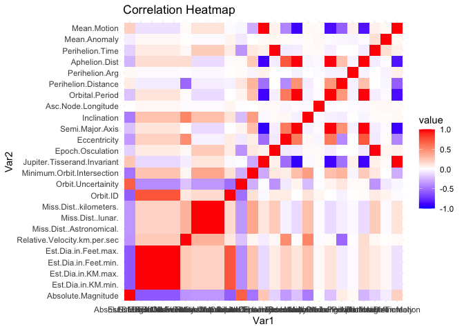

```r
# Visualization - create a heatmap of the correlation matrix
cor_melted <- melt(cor_matrix)
ggplot(data = cor_melted, aes(Var1, Var2, fill = value)) +
  geom_tile() +
  scale_fill_gradient2(low = "blue", mid = "white", high = "red", midpoint = 0, limit = c(-1, 1)) +
  theme_minimal() +
  labs(title = "Correlation Heatmap")
```

```r
# Find highly correlated variable pairs
threshold <- 0.7
highly_correlated <- which(cor_matrix > threshold & cor_matrix < 1, arr.ind = TRUE)
print(highly_correlated)
```

```
                        row col
```

Est.Dia.in.KM.max. 3 2 Orbit.ID 10 2 Est.Dia.in.KM.min. 2 3 Est.Dia.in.Feet.min. 4 3 Est.Dia.in.Feet.max. 5 3 Orbit.ID 10 3 Est.Dia.in.KM.max. 3 4 Est.Dia.in.Feet.max. 5 4 Orbit.ID 10 4 Est.Dia.in.KM.max. 3 5 Est.Dia.in.Feet.min. 4 5 Orbit.ID 10 5 Miss.Dist..lunar. 8 7 Miss.Dist..kilometers. 9 7 Miss.Dist..Astronomical. 7 8 Miss.Dist..kilometers. 9 8 Miss.Dist..Astronomical. 7 9 Miss.Dist..lunar. 8 9 Est.Dia.in.KM.min. 2 10 Est.Dia.in.KM.max. 3 10 Est.Dia.in.Feet.min. 4 10 Est.Dia.in.Feet.max. 5 10 Mean.Motion 25 13 Perihelion.Time 23 14 Aphelion.Dist 22 15 Orbital.Period 19 16 Aphelion.Dist 22 16 Semi.Major.Axis 16 19 Aphelion.Dist 22 19 Eccentricity 15 22 Semi.Major.Axis 16 22 Orbital.Period 19 22 Epoch.Osculation 14 23 Jupiter.Tisserand.Invariant 13 25

```r
# Remove redundant variables
reduced_df <- df[, -unique(highly_correlated[, 2])]
```

# Remove Redundant features having high correlation

```r
names_to_remove <- c(

  "Est.Dia.in.Feet.min.",
  "Miss.Dist..lunar.",
  "Miss.Dist..Astronomical.",
  "Est.Dia.in.KM.min.",
  "Est.Dia.in.Feet.max.",
  "Perihelion.Time",
  "Aphelion.Dist",
  "Orbital.Period",
  "Semi.Major.Axis",
  "Epoch.Osculation"
)

# Create a new dataframe excluding redundant variables
reduced_df <- df[, !names(df) %in% names_to_remove]
reduced_df
```

[output not shown]